# Forest Fires

Christina Sousa

March 12, 2019

# Introduction

The data are from forest fires occuring in the Montesinho National Park in northeast Portugal between January 2000 and December 2003. They come to us by way of Paulo Cortez and Anibal Morais at the University of Minho, in Guimaraes, Portugal. Our goal is to use 12 predictors to model the total burned area of forest fires within the park. This will hopefully give insight as to what conditions might indicate more severe or larger fires.

The variables in the data are given by:

1. X - x-axis spatial coordinate within the Montesinho park map: 1 to 9
2. Y - y-axis spatial coordinate within the Montesinho park map: 2 to 9
3. month - month of the year: “jan” to “dec”
4. day - day of the week: “mon” to “sun”
5. FFMC - FFMC index from the FWI system: 18.7 to 96.20
6. DMC - DMC index from the FWI system: 1.1 to 291.3
7. DC - DC index from the FWI system: 7.9 to 860.6
8. ISI - ISI index from the FWI system: 0.0 to 56.10
9. temp - temperature in Celsius degrees: 2.2 to 33.30
10. RH - relative humidity in %: 15.0 to 100
11. wind - wind speed in km/h: 0.40 to 9.40
12. rain - outside rain in mm/m2 : 0.0 to 6.4
13. area - the burned area of the forest (in ha): 0.00 to 1090.84 (this output variable is very skewed towards 0.0, thus it may make sense to model with the logarithm transform).

# Exploratory Data Analysis

We begin the analysis by reading in the data and plotting it.

```r
#data file can be obtained at https://archive.ics.uci.edu/ml/machine-learning-databases/forest-fires/
#read data into r
forest <-read.csv("forestfires.csv")
head(forest)
```

```
##   X Y month day FFMC  DMC    DC  ISI temp RH wind rain area
## 1 7 5   mar fri 86.2 26.2  94.3  5.1  8.2 51  6.7  0.0    0
## 2 7 4   oct tue 90.6 35.4 669.1  6.7 18.0 33  0.9  0.0    0
## 3 7 4   oct sat 90.6 43.7 686.9  6.7 14.6 33  1.3  0.0    0
## 4 8 6   mar fri 91.7 33.3  77.5  9.0  8.3 97  4.0  0.2    0
## 5 8 6   mar sun 89.3 51.3 102.2  9.6 11.4 99  1.8  0.0    0
## 6 8 6   aug sun 92.3 85.3 488.0 14.7 22.2 29  5.4  0.0    0
```

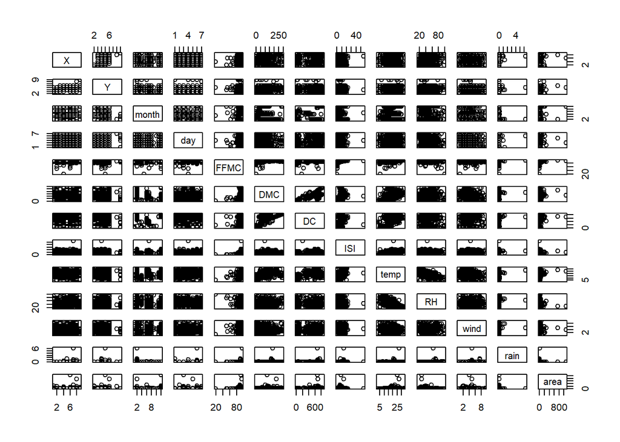

```r
pairs(forest)
```

It is notable that there are 247 records with an `area` value of 0. The values of `area` also range over several orders of magnitude. This suggests a log transformation of the response will be useful. This is explained by Cortez and Morais as a general trend with forest fire data observed in various locations: either the fires are extinguished quickly and burn less than $100m^2$ of area, or they are not easily contained and end up burning a large area.

There is also a trend with respect to observation order here: this is likely due to the fact that when combining the two data sets, the first set was sorted by `area`, while the second set was ordered chronologically.

```r
length(which(forest$area==0))
```

```
## [1] 247
```

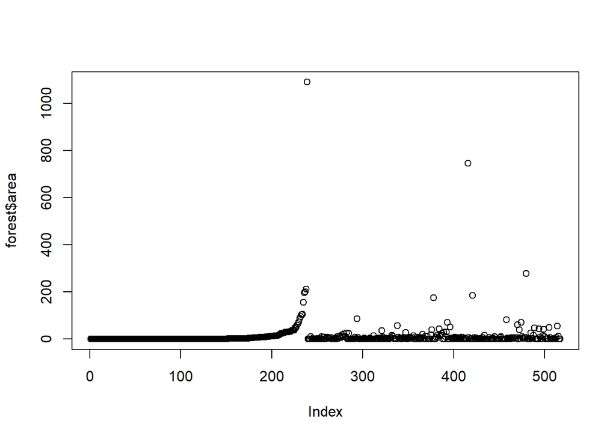

```r
plot(forest$area)
```

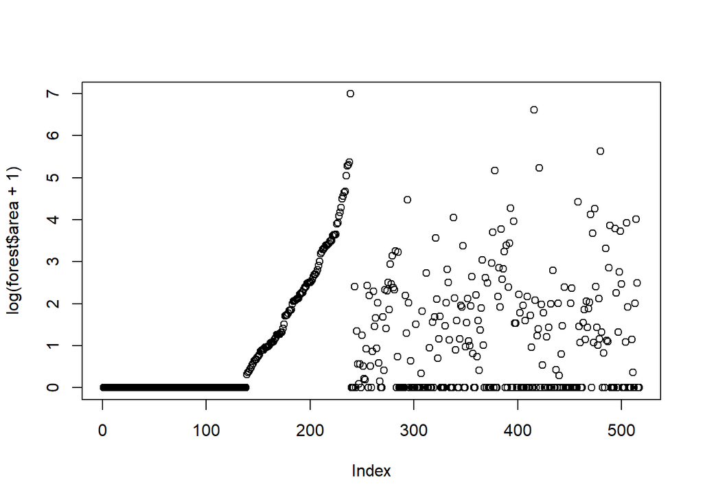

```r
plot(log(forest$area+1))
```

We log transform `area` and replot the data:

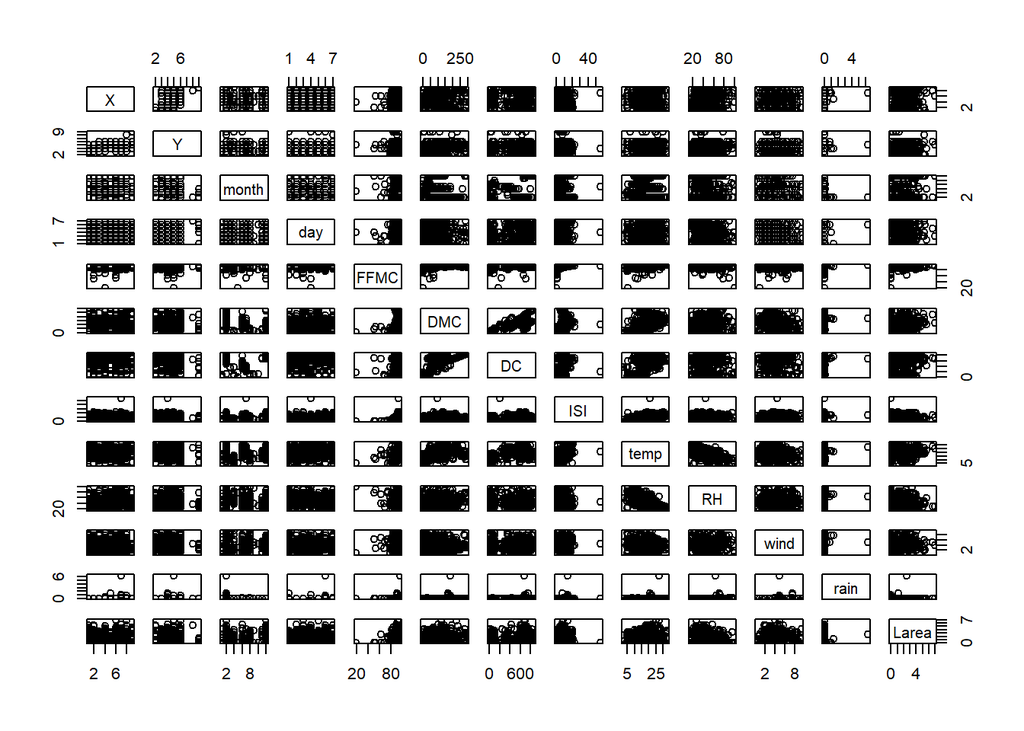

```r
forest2<-cbind(forest[,1:12],log(forest$area+1))
colnames(forest2)[13]<-"Larea"
pairs(forest2)
```

There are also many data points for which the value of `rain` is zero. This makes sense, considering that forest fires are probably more likely to break out on dry days. Still, this variable might also indicate lightning storms, which can also cause a fire to break out. It might make sense to convert this to a factor variable rather than a numeric variable, or even a binomial variable with “rain”=1 and “no rain”=0.

There appear to be some outliers, particularly in `area`, `rain`, `ISI`, and `FFMC`. We investigate further.

```r
which(forest$area>600)
```

```
## [1] 239 416
```

```r
which(forest$rain>5)
```

```
## [1] 500
```

```r
which(forest$ISI>40)
```

```
## [1] 23
```

```r
which(forest$FFMC<20)
```

```
## [1] 380
```

```r
forest[c(239,416,500,23,380),]
```

```
##     X Y month day FFMC   DMC    DC  ISI temp  RH wind rain    area
## 239 6 5   sep sat 92.5 121.1 674.4  8.6 25.1  27  4.0  0.0 1090.84
## 416 8 6   aug thu 94.8 222.4 698.6 13.9 27.5  27  4.9  0.0  746.28
## 500 7 5   aug tue 96.1 181.1 671.2 14.3 27.3  63  4.9  6.4   10.82
## 23  7 4   jun sun 94.3  96.3 200.0 56.1 21.0  44  4.5  0.0    0.00
## 380 4 5   jan sun 18.7   1.1 171.4  0.0  5.2 100  0.9  0.0    0.00
```

```r
# We can calculate the Cooks distances to verify which points may be influential.
cooks.distances<-cooks.distance(lm(Larea~.,dat=forest2))
summary(cooks.distances)
```

```
##      Min.   1st Qu.    Median      Mean   3rd Qu.      Max.      NA's
## 0.0000000 0.0003186 0.0007533 0.0041308 0.0014963 0.9525350         1
```

```r
which(cooks.distances>.5)
```

```
## 500
## 500
```

```r
cooks.distances[c(239,416,500,23,380)]
```

```
##         239         416         500          23         380
## 0.012526169 0.018287663 0.952535039 0.005791183 0.018797428
```

```r
qf(0.5,ncol(forest2)+1,nrow(forest2)-ncol(forest2)-1)
```

```
## [1] 0.9540749
```

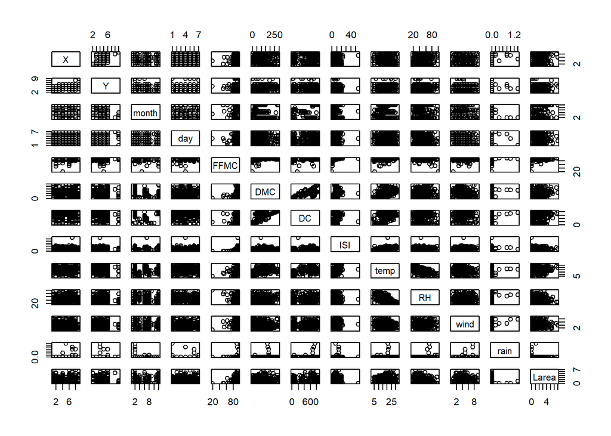

```r
forest3<-forest2[-500,]
pairs(forest3)
```

We recalculate the Cook’s Distances with this observation removed. These look much better now.

```r
cooks.distances2<-cooks.distance(lm(Larea~.,dat=forest3))
summary(cooks.distances2)
```

```
##      Min.   1st Qu.    Median      Mean   3rd Qu.      Max.      NA's
## 0.0000000 0.0003382 0.0007567 0.0024579 0.0015138 0.1572292         1
```

```r
which(cooks.distances2>.5)
```

```
## named integer(0)
```

Note that `DMC` and `DC` appear to be linearly correlated. There may also be correlation between `temp` and `ISI` and `RH` and `temp`. This is probably because temperature is used in the calculation of these indexes. There also appears to be an interesting curvilinear relationship between `DMC` and `FFMC` as well as `DMC` and `ISI`. Indeed it seems like these individual indexes have a good deal of overlap. We generate a correlation matrix to check for linear dependence. It appears that `DC` and `DMC`, `temp` and `DC`, and `FFMC` and `ISI` have somewhat high linear correlation, along with `temp` and `RH`. Also `temp` and `DMC` appear to be somewhat linearly correlated. To summarize, there is quite a bit of multicollinearity in this data. This may be because the fire indexes are in part based on the various weather variables, and because weather variables such as temperature and humidity are related to one another.

```r
cor(forest3[,-c(1,2,3,4)])
```

```
##              FFMC         DMC          DC         ISI        temp
## FFMC   1.00000000  0.38132136  0.32995034  0.53077738  0.43003669
## DMC    0.38132136  1.00000000  0.68209369  0.30341197  0.46800964
## DC     0.32995034  0.68209369  1.00000000  0.22838928  0.49594044
## ISI    0.53077738  0.30341197  0.22838928  1.00000000  0.39234087
## temp   0.43003669  0.46800964  0.49594044  0.39234087  1.00000000
## RH    -0.30387204  0.07152820 -0.04035926 -0.13544405 -0.53237993
## wind  -0.02946479 -0.10654037 -0.20403783  0.10588156 -0.22902226
## rain   0.04903261  0.09237589  0.04811082  0.06144466  0.02838974
## Larea  0.04501800  0.06521991  0.06549805 -0.01255885  0.05090412
##                RH        wind        rain       Larea
## FFMC  -0.30387204 -0.02946479  0.04903261  0.04501800
## DMC    0.07152820 -0.10654037  0.09237589  0.06521991
## DC    -0.04035926 -0.20403783  0.04811082  0.06549805
## ISI   -0.13544405  0.10588156  0.06144466 -0.01255885
## temp  -0.53237993 -0.22902226  0.02838974  0.05090412
## RH     1.00000000  0.06841692  0.16545200 -0.05594837
## wind   0.06841692  1.00000000  0.12934372  0.06612049
## rain   0.16545200  0.12934372  1.00000000 -0.05543223
## Larea -0.05594837  0.06612049 -0.05543223  1.00000000
```

```r
summary(cor(forest3[,-c(1,2,3,4)]))
```

```
##       FFMC               DMC                 DC
##  Min.   :-0.30387   Min.   :-0.10654   Min.   :-0.20404
##  1st Qu.: 0.04502   1st Qu.: 0.07153   1st Qu.: 0.04811
##  Median : 0.32995   Median : 0.30341   Median : 0.22839
##  Mean   : 0.27031   Mean   : 0.32860   Mean   : 0.28951
##  3rd Qu.: 0.43004   3rd Qu.: 0.46801   3rd Qu.: 0.49594
##  Max.   : 1.00000   Max.   : 1.00000   Max.   : 1.00000
##       ISI                temp                RH
##  Min.   :-0.13544   Min.   :-0.53238   Min.   :-0.53238
##  1st Qu.: 0.06144   1st Qu.: 0.02839   1st Qu.:-0.13544
##  Median : 0.22839   Median : 0.39234   Median :-0.04036
##  Mean   : 0.27492   Mean   : 0.23380   Mean   : 0.02638
##  3rd Qu.: 0.39234   3rd Qu.: 0.46801   3rd Qu.: 0.07153
##  Max.   : 1.00000   Max.   : 1.00000   Max.   : 1.00000
##       wind               rain              Larea
##  Min.   :-0.22902   Min.   :-0.05543   Min.   :-0.05595
##  1st Qu.:-0.10654   1st Qu.: 0.04811   1st Qu.:-0.01256
##  Median : 0.06612   Median : 0.06144   Median : 0.05090
##  Mean   : 0.08897   Mean   : 0.16875   Mean   : 0.12987
##  3rd Qu.: 0.10588   3rd Qu.: 0.12934   3rd Qu.: 0.06550
##  Max.   : 1.00000   Max.   : 1.00000   Max.   : 1.00000
```

There do not appear to be any immediately evident variables that look like strong predictors for `Larea`. We proceed to seeking out suitable transformations of these variables that may reveal more evidence, by applying the Yeo-Johnson method. Note that some of the variable values have zero values, so the Box-Cox method won’t work for this data. The `car` package function `powerTransform` indeed suggests that some transformations may be in order.

```r
require(car)
summary(forest3)
```

```
##        X               Y             month      day          FFMC
##  Min.   :1.000   Min.   :2.000   aug    :183   fri:85   Min.   :18.70
##  1st Qu.:3.000   1st Qu.:4.000   sep    :172   mon:74   1st Qu.:90.20
##  Median :4.000   Median :4.000   mar    : 54   sat:84   Median :91.60
##  Mean   :4.665   Mean   :4.298   jul    : 32   sun:95   Mean   :90.63
##  3rd Qu.:7.000   3rd Qu.:5.000   feb    : 20   thu:61   3rd Qu.:92.90
##  Max.   :9.000   Max.   :9.000   jun    : 17   tue:63   Max.   :96.20
##                                  (Other): 38   wed:54
##       DMC               DC             ISI              temp
##  Min.   :  1.10   Min.   :  7.9   Min.   : 0.000   Min.   : 2.20
##  1st Qu.: 67.03   1st Qu.:436.6   1st Qu.: 6.475   1st Qu.:15.50
##  Median :108.30   Median :663.0   Median : 8.400   Median :19.30
##  Mean   :110.74   Mean   :547.7   Mean   : 9.011   Mean   :18.87
##  3rd Qu.:141.57   3rd Qu.:713.9   3rd Qu.:10.725   3rd Qu.:22.80
##  Max.   :291.30   Max.   :860.6   Max.   :56.100   Max.   :33.30
##
##        RH              wind            rain              Larea
##  Min.   : 15.00   Min.   :0.400   Min.   :0.000000   Min.   :0.0000
##  1st Qu.: 32.75   1st Qu.:2.700   1st Qu.:0.000000   1st Qu.:0.0000
##  Median : 41.50   Median :4.000   Median :0.000000   Median :0.4187
##  Mean   : 44.25   Mean   :4.016   Mean   :0.009302   Mean   :1.1084
##  3rd Qu.: 53.00   3rd Qu.:4.900   3rd Qu.:0.000000   3rd Qu.:2.0212
##  Max.   :100.00   Max.   :9.400   Max.   :1.400000   Max.   :6.9956
##
```

```r
summary(powerTransform(cbind(FFMC,DMC,DC,ISI,temp,RH,wind,rain)~1,forest3,family="yjPower"))
```

```
## yjPower Transformations to Multinormality
##      Est Power Rounded Pwr Wald Lwr Bnd Wald Upr Bnd
## FFMC    8.9370        8.94       7.9253       9.9487
## DMC     0.3237        0.33       0.2577       0.3898
## DC      1.2192        1.22       1.0787       1.3596
## ISI     0.0440        0.00      -0.0481       0.1362
## temp    1.0816        1.00       0.9128       1.2503
## RH      0.1973        0.33       0.0033       0.3913
## wind    0.4431        0.50       0.2392       0.6470
## rain -149.6945     -149.69    -162.6108    -136.7782
##
##  Likelihood ratio test that all transformation parameters are equal to 0
##                                          LRT df       pval
## LR test, lambda = (0 0 0 0 0 0 0 0) 5764.374  8 < 2.22e-16
```

# Citations

P. Cortez and A. Morais. A Data Mining Approach to Predict Forest Fires using Meteorological Data. In J. Neves, M. F. Santos and J. Machado Eds., New Trends in Artificial Intelligence, Proceedings of the 13th EPIA 2007 - Portuguese Conference on Artificial Intelligence, December, Guimaraes, Portugal, pp. 512-523, 2007. APPIA, ISBN-13 978-989-95618-0-9.